# CHAPTER A19

# 翼応力解析入門

## A19.1 代表的な翼構造の配置

空力的な理由から、翼の横断面は一般に翼型断面と呼ばれる流線型でなければならない。飛行中の空力的な力は、その大きさ、方向、位置が変化する。同様に、さまざまな着陸動作においても荷重の大きさ、方向、位置が変化するため、要求される構造は、引張、圧縮、曲げ、ねじりが複合した荷重に対して効率的に抵抗できるものでなければならない。ねじり剛性を提供するために、翼型表面の一部を金属製の外板で覆い、さらに1つ以上の内部金属ウェブを加えて単一の閉じたセル、または多細胞の翼横断面を作成することができる。亜音速機では比較的薄い外板表面は、ねじりせん断応力や引張に抵抗するのには効率的であるが、翼の曲げによる圧縮応力に抵抗するのには極めて非効率である。強度効率を高めるために、一般にフランジストリンガーと呼ばれる翼幅方向の補強部材が外板の内側に取り付けられる。外板表面を翼型形状に保持し、表面の空気圧をセル構造のビームに伝達する媒体とするために、翼弦方向のフォーマーやリブが追加される。大きな集中荷重をセル構造のビームに伝達するために、一般に隔壁（バルクヘッド）と呼ばれる重いリブが使用される。

図 A19.1 および 図 A19.2 は、亜音速機における翼横断面の代表的な構造配置を示している。外板表面は比較的薄い。一般に、翼構造のフランジ配置は次の2つのタイプに分類できる。（1）フランジ材料が内部ウェブに直接接続される集中フランジ型、および（2）内部ウェブの間の外板にストリンガーが取り付けられる分散フランジ型である。

図 A19.3 は、超音速機用の翼横断面のいくつかの構造配置を示している。超音速翼の形状は、亜音速機に比べて比較的薄い。

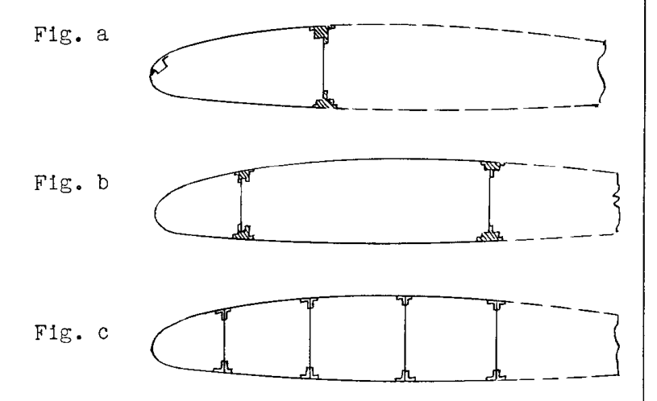

集中フランジ型の翼ビーム

破線は二次構造を表す。多くの場合、この部分は布張りである。

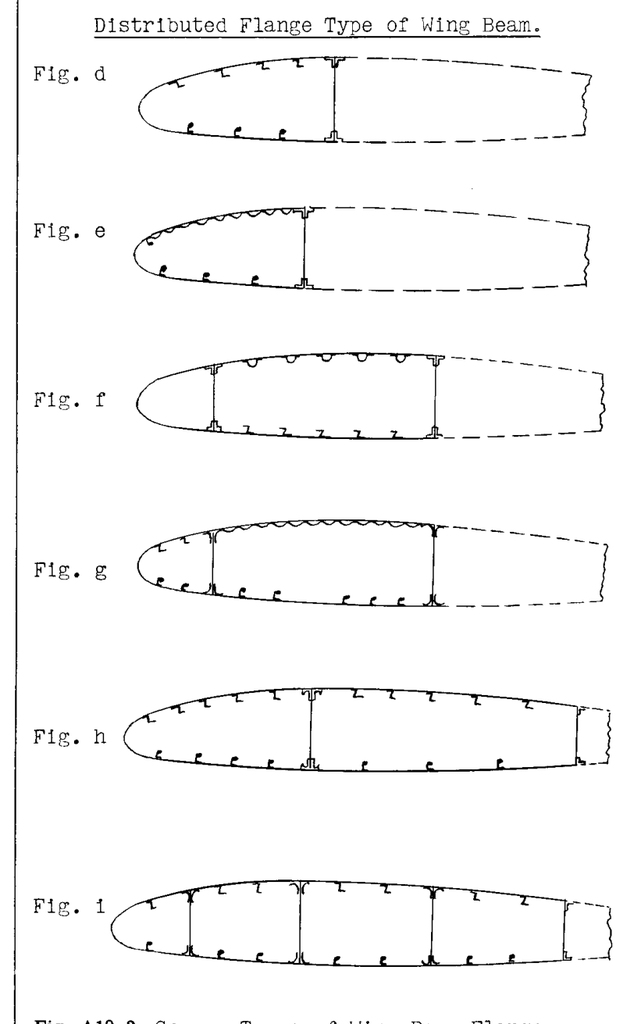

代表的な翼ビームフランジ配置の種類

## A19.2 翼構造の解析

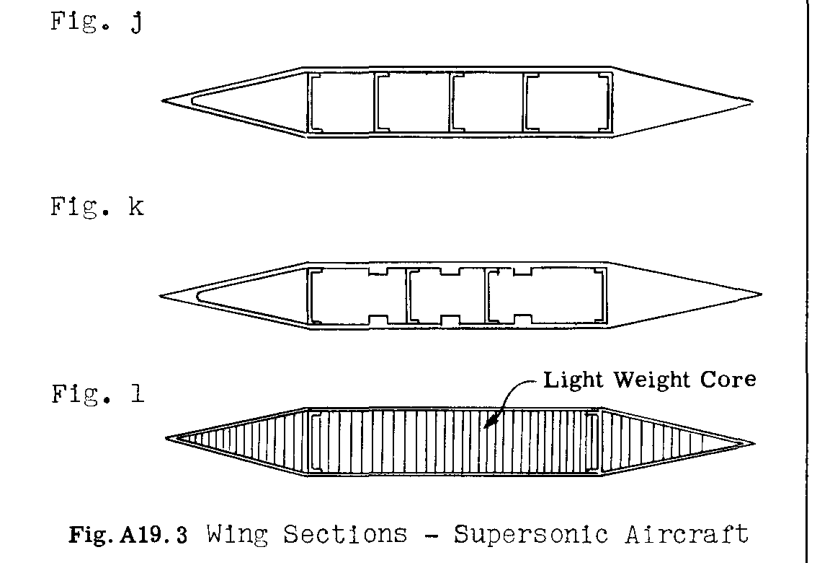

超音速機の翼断面

高い表面圧力に耐え、十分な強度を得るためには、通常、はるかに厚い翼外板が必要となる。現代のフライス盤は、外板の厚さをテーパー状に加工することを可能にしている。より多くのフランジ材料を得るために、図 k に示すように、厚い外板に一体型フランジユニットが加工される。

一般に、フランジ材料は $Z$ 方向において最大の慣性モーメントを与えるように配置されるべきであり、これは一般に、フランジ材料を前縁から翼弦の15～50%の間に配置することを意味する。

構造ボックスビームの後方の二次的または分散構造は、可能な限り軽量に作られるべきであり、したがって、一般にボックスビームの後部閉鎖ウェブが前方にあるほど、翼構造全体として軽量になる。

主要な翼幅方向フランジ部材のレイアウトにおいて、部材の方向転換に必要なスプライスや横方向補強材は重量増加を招くため、曲がりや方向の変化は避けるべきである。フランジ部材をスプライスする必要がある場合は、最大断面の領域でスプライスしないように注意する必要がある。さらに、一般にフィッティングの数が少ないほど、構造は軽量になる。

### (1) 軽量化

構造設計者は常に、生産およびコストの観点から実用的な最小重量を目指して努力している。極限許容応力が高いほど、構造は軽量になる。図 A19.1 の (a, b, c) に示す集中フランジ型の翼構造は、フランジ部材がウェブとカバーシートの両方によって安定化され、柱作用が排除されるため、高い許容圧縮フランジ応力を可能にし、設計応力をフランジ部材のクリップリング応力に近づけることができる。フランジ部材の数が少ないため、必要なサイズまたは厚さは比較的大きくなり、高いクリップリング応力が得られる。一方で、このタイプの設計は、圧縮側における金属カバーの有効性を十分に発揮できないため、これとフランジ部材の重量削減とのバランスをとる必要がある。

分散型のフランジ配置（図 A19.2）では、圧縮側のカバーの一部が、密に配置されたストリンガーまたはコルゲーションに取り付けられているため、有効に機能する。しかし、セルウェブ間のフランジストリンガーは、リブまたはバルクヘッドの点でのみ支持されているため、セルカバーに対して垂直な柱作用を受ける。翼リブの間隔をフランジストリンガーの深さの12～18倍未満にすることは実用的ではないため、この要因によりフランジの許容圧縮応力が低下する。したがって、他に制御要因がなければ、上記のどちらが最も軽くなるかを計算によって容易に決定できる。一般に、翼へのねじり力が小さく、薄いカバーのみが必要な場合は、集中フランジ型の翼構造が最も軽くなるはずである。

### (2) 翼と胴体の結合

飛行機が低翼または高翼タイプの場合、翼構造全体を飛行機胴体を貫通して継続させることができる。しかし、中翼またはセミ低翼タイプでは、制限により翼全体を胴体内に延長できない場合があり、一部のせん断ウェブおよび翼カバーを胴体の側面で終端させる必要がある。分散フランジ型のセル構造が使用されている場合、フランジストリンガーの軸荷重は胴体を貫通する部材に伝達されなければならない。この大きな荷重の伝達を行うには構造重量が必要となるため、集中フランジ型のボックス構造が最適な構造タイプとなる可能性がある。

### (3) 翼表面のカットアウト

表面全体で構造の連続性が維持される理想的な配置は、格納式着陸装置、郵便室、爆弾および銃のコンパートメントなどのアイテムのための翼表面のカットアウトのため、実際の飛行機設計ではめったに得られない。分散フランジ型のボックスビームが使用されている場合、それらは各カットアウトで中断されるため、開口部の周囲にフランジ荷重を逃がす手段を提供する必要があり、応力解析では通常、保守的な重複仮定がなされるため、重量が増加する配置となる。大きな開口部の周囲でフランジ荷重を伝達するための追加の構造とリベット締めは、生産コストを大幅に増加させる。

着陸装置や他の多くの装備品において、翼のカットアウトは下面に限定されているため、図 A19.4 に示すような構造配置が極めて一般的である。上面は分散フランジ型であるのに対し、下面のフランジ材料はボックスの2つの下隅に集中している。通常の飛行状態では、下面は引張状態にあるため、せん断遅れの影嚮を無視すれば、カットアウト間のセル外板カバーは曲げに対して同様に有効である。負の加速度がかかる飛行状態では、下面は圧縮状態にあるため、隅フランジ間の外板カバーは曲げに対して無効になる。しかし、これらの飛行状態における荷重倍数は通常の飛行荷重倍数の約半分であるため、曲げにおける下部外板のこの無効性は通常、致命的ではない。

カットアウトはまた、図 c および i に示すような中間内部せん断ウェブの連続性を破壊し、これらの中断されたウェブにおけるせん断荷重は、カットアウトの両側にある特別なバルクヘッドによって開口部の周囲に伝達されなければならず、これは重量増加を意味する。

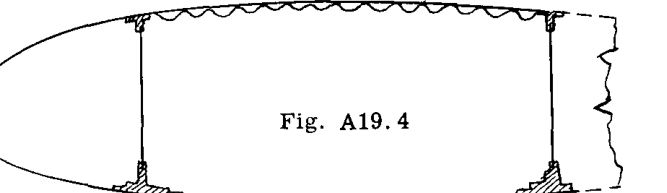

翼下面のカットアウトの例

多くの場合、動力装置の設置、着陸装置の収納部などのために、前縁部分のカットアウトが必要となる。さらに、多くの飛行機では、胴体近くの翼部分に配置されている多くの装備品を検査するために、前縁部分を取り外し可能にすることが望ましい。そのような場合、内部ウェブは翼断面の前部近くに配置されるべきである。

ボックスビーム構造の中央部分の検査用アクセスドアは、通常、翼の下面に配置される。これらは通常、2本の翼幅方向ストリンガーにネジで固定されており、取り外し可能なパネルは曲げおよびせん断荷重に抵抗するのに有効である。（図 A19.5 参照）

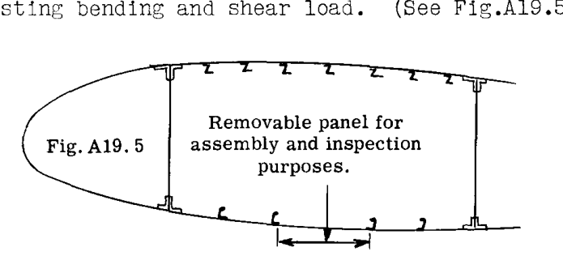

組み立ておよび検査用の取り外し可能パネル

翼構造ボックスのカットアウトは、セルのねじり剛性の連続性を破壊するため、カットアウトの周囲にねじり力を伝達するために特別な考慮を払わなければならない。この特別な問題については後で説明する。

### (4) 折りたたみ翼

特定の飛行機、特に空母艦載機では、外側の翼パネルを上方に折りたたむための対策を講じる必要がある。これにより、外側翼パネルと中央翼パネルの間に明確なヒンジポイントが決定される。分散フランジ型の構造を使用する場合、フランジ力を集めてフィッティングポイントに伝達する必要があるため、少数の翼幅方向部材からなる妥協案が一般的な実務である。

### (5) 翼フラッターの防止

現代の飛行機によって得られる高速化に伴い、翼の構造レイアウトおよび設計において、翼フラッターの防止に細心の注意を払わなければならない。一般に、臨界フラッター速度は、翼のねじり剛性に大きく依存する。質量の重心が翼弦の25%点より後方に移動すると、臨界フラッター速度が低下するため、翼の重量を前方に維持することが重要である。空気が「圧縮性」の影響を及ぼすようになる高速域では、翼にかかるねじり力が増大するため、外板を厚くするか、セルを大きくする必要がある。フラッター防止のための設計は、高度に専門化された問題である。

### (6) 生産の容易さとコスト

航空機産業は大量生産産業であるため、翼の構造レイアウトは生産方法を考慮しなければならない。現時点での一般的な傾向は、翼と胴体の構造を設計して、さまざまな部品のサブアセンブリを作成し、それを最終的に結合して翼パネルの最終組み立てを行うことである。このプロセスを効率的に行うには、翼構造の詳細とレイアウトを慎重に検討する必要がある。写真 A19.6 はサブアセンブリを示している。

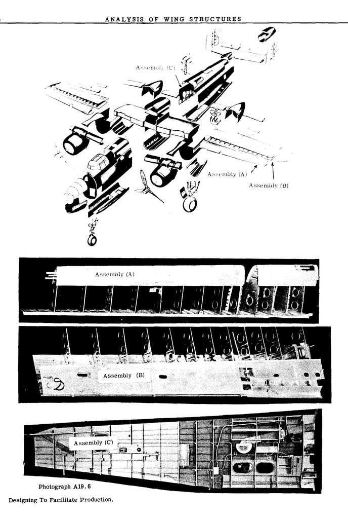

生産を容易にする設計

主要な航空機会社の一翼の構造部品の分解図。これらのユニットの製造と組み立てにより、最終組み立ての前に多くの機器の取り付けが可能になる。

## A19.3 翼強度要件

翼の構造設計において、2つの主要な強度要件を満たす必要がある。それらは次のとおりである。 (1) 制限荷重（または実用荷重）の下で、構造のいかなる部分も材料の降伏応力を超える応力を受けてはならない。一般に、降伏応力とは、1インチあたり0.002インチの永久ひずみを生じさせる応力である。制限荷重という用語は、飛行機がその運用寿命中に遭遇する可能性のある最大荷重を指す。 (2) 構造はまた、破断や崩壊、言い換えれば破損することなく、設計荷重を支持しなければならない。設計荷重の大きさは、制限荷重に安全率（F.S.）を乗じたものに等しい。一般に、航空機の安全率は1.5であるため、構造は破損することなく制限荷重の1.5倍に耐えなければならない。ミサイルでは、人間の乗客が関与しないため、安全率はこれより低く、現時点では1.15から1.25の範囲にあるようである。

航空機の安全率は、他の構造設計分野と比較してかなり低いが、これは主に、有効荷重と性能に関して有用な輸送手段を得るために、重量削減が非常に重要であるためである。安全性は最も重要な設計要件であるため、構造が破損することなく設計荷重を支持することを確認するために、広範な静的および動的試験によって理論設計の正確性を検証しなければならない。

## A19.4 翼応力解析方法

本書のこれまでの章の多くでは、静定構造と不静定構造の両方について内力が計算された。静定構造の内力は、静的釣り合い方程式のみを使用して見つけることができる。部材の全体的な構造配置は必要であるが、個々の部材のサイズや形状は必要ない。言い換えれば、設計とは内力を見つけ、その荷重を安全かつ効率的に支持する部材を提供することからなる。不静定構造では、すべての内部応力を見つけるために、静的釣り合い方程式以外の追加の方程式が必要である。追加の方程式は、構造の歪みの考慮から提供される。これは、内部応力を決定する前に、構造の部材のサイズ、形状、および材料の種類を知らなければならないことを意味する。この事実は、試行錯誤の手法が必要であることを意味する。もう1つの重要な違いは、静定翼構造は安定性を生み出すのにちょうど十分な部材を有しており、1つの部材が取り外されるか破損すると、通常、構造全体が破損するのに対し、不静定構造は静的安定性に必要な数よりも1つ以上の追加部材を有しているため、一部の部材が破損しても構造全体が崩壊することはない。言い換えれば、構造はフェイルセーフ特性を有しており、一部の部材が過負荷になった場合に内応力の再分配が行われ得る。一般に、不静定構造は、より軽量で、全体的なたわみが小さくなるように設計できる。

### 不静定翼構造の応力解析方法

一般に、次の2つの方法が一般的に使用されている。 (1) 簡略化した仮定を伴う曲げビーム理論。 (2) 仮想仕事、ひずみエネルギーなどのさまざまな方法により、弾性理論の原理を適用して、不静定力および応力を解く方法。

2番目の方法は、仮定が少なくて済むため、間違いなくより正確である。複数のセルと多くの翼幅方向ストリンガーで構成される翼構造は、多自由度の不静定構造である。高速計算機の開発前は、計算要件が不可能または全く実用的でなかったため、いわゆる厳密な方法は使用できなかった。しかし、現代のコンピュータ設備は状況を一変させ、厳密な方法が航空機の構造解析でますます使用されるようになっている。第7章および第8章のA7.9節およびA8.10節では、コンピュータ設備で使用するためのたわみおよび応力を求めるマトリックス法を紹介している。

## A19.5 例題 1. 3フランジ単一セル翼

図 A19.7 は、片持ち翼の一部を示している。ねじり強度を提供するために、内部ウェブABと、このウェブの前方にある金属外板カバーによって、単一の閉じたセル (1) が形成されている。薄い板は圧縮応力に抵抗する能力が比較的低いため、効率的な曲げ抵抗を発揮するために3つのフランジストリンガーA、B、Cが追加されている。スパABの後方の構造は二次構造と呼ばれ、翼弦方向の翼リブに取り付けられた薄い金属または布のカバーで構成されている。したがって、この部分の空気荷重は、リブによって前方の単一セルビームに伝達される。

翼は多くの飛行状態にさらされる。応用荷重を計算するエンジニアは、通常、結果として生じるせん断力とモーメントを、便利な $x$ 、 $y$ 、 $z$ 軸のセットに関連付ける。図 A19.7 は、これらの基準軸の位置を示している。応力エンジニアの仕事は、これらの荷重に安全かつ効率的に抵抗する構造を提供することである。一般的な手順は、翼幅方向に沿ったいくつかのステーションにおいて、セルの横断面のすべての部分における応力または荷重を求め、これらの荷重または応力から、必要な面積、厚さ、および形状をプロポーショニングすることである。

この例では、内力はステーション240の1つの断面についてのみ計算される。クリティカルな飛行状態からの設計クリティカル荷重は次の通りであると仮定する。

$$M_x = 1,100,000 \text{ in.lb. } \quad V_z = 11,500 \text{ lb.}$$
$$M_z = 80,000 \text{ in.lb. } \quad V_x = 700 \text{ lb.}$$
$$M_y = 460,500 \text{ in.lb.}$$

図 A19.8 は、原点を点 (0) とする基準軸に関連するこれらのせん断力とモーメントを示している。モーメントは、二重矢印のベクトルで表されている。モーメントの向きは右ねじの法則に従う。

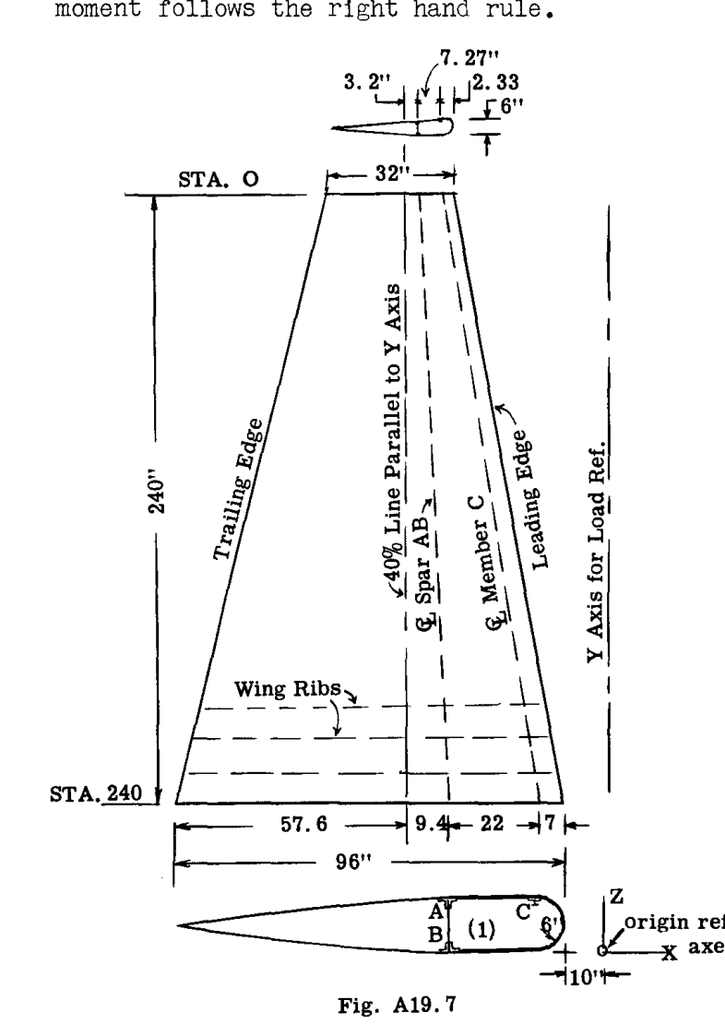

翼断面の基準軸

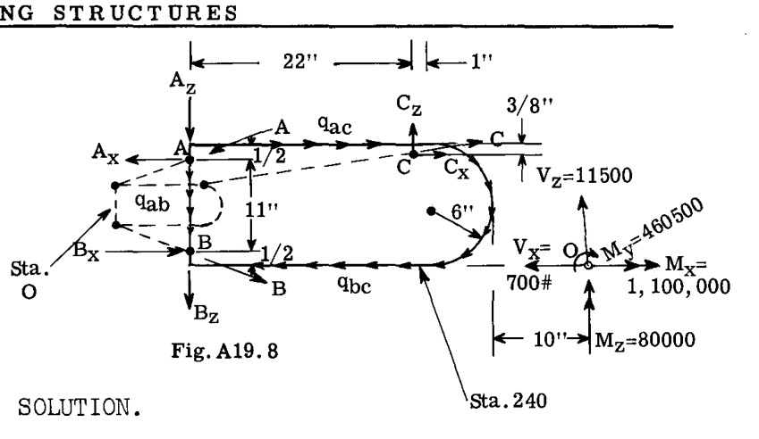

翼幅方向の寸法と作用荷重

### 解法

**仮定**: 3つのフランジストリンガーA、B、Cが、 $Z$ 軸および $X$ 軸まわりの曲げモーメントに対する全抵抗を発揮すると仮定する。圧縮下の外板については、外板が比較的低い応力で座屈するため、この仮定はほぼ正しい。薄板は引張応力に耐えることができるため、この仮定は保守的である。しかし、薄い外板カバーはせん断応力に抵抗しなければならないため、この保守的な仮定を採用する。この近似的な仮定の主な利点は、構造を静定にすることである。

図 A19.8 は、ステーション240でカットされた翼を示している。未知の力は、ストリンガーA、B、Cにおける3つの軸荷重と、3つの外板パネルにおける3つのせん断流 $q_{ab}$ 、 $q_{ac}$ 、 $q_{bc}$ であり、合計6つの未知数となる。空間構造に対して6つの静的釣り合い方程式が利用可能であるため、この構造は静定である。

フランジ部材A、B、Cのサイズと形状は未知であるため、図 A19.8 のドットで示されるように、それらの図心位置を推測する。3つの各ストリンガーにおける軸荷重は、図に示すように、その $x$ 、 $y$ 、 $z$ 成分に置き換えられている。外部から加えられる荷重は、図 A19.8 に示すように、基準原点 (0) に与えられる。 $Y$ 軸は横断面に対して垂直である。

ここで、6つの未知数を見つけるために静的釣り合い方程式を適用する。

$C_y$ を求めるために、点AとBを通る $Z$ 軸まわりのモーメントをとる。 $C_y$ は横断面に対して垂直である。

$$\Sigma M_{z(ab)} = -22 C_y + 80000 = 0 \quad \text{より} \quad C_y = 3636 \text{ lb.}$$

結果は正の符号で得られ、仮定した引張の向きが正しかったことを示している。

$B_y$ を求めるために、(A) を通る $X$ 軸まわりのモーメントをとる。 $B_y$ は断面に対して垂直である。

$$\Sigma M_{x(A)} = -11 B_y + 1,100,000 + 3636 \times 0.125 = 0$$

これより、

$$B_y = 100,043 \text{ lb. (仮定通りの引張)}$$

$A_y$ を求めるために、 $\Sigma F_y = 0$ とする。

$$\Sigma F_y = -100,043 - 3636 + A_y = 0$$

これより、

$$A_y = 103,679 \text{ lb. (仮定通りの圧縮)}$$

3つのストリンガーの方向が分かっているため、単純な幾何学からストリンガー荷重の $X$ および $Z$ 成分を見つけることができる。

図 A19.7 に示された寸法から、3つのストリンガーの $y$ 、 $x$ 、 $z$ 長さ成分は以下のようになる。

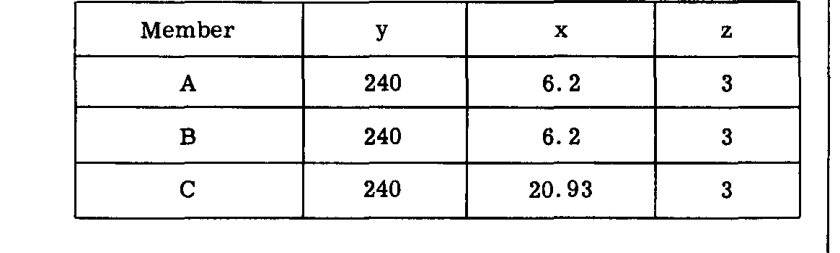

Member Table

したがって、力成分は以下の通りである。

$$A_z = 103679 \times \frac{3}{240} = 1296 \text{ lb.}$$
$$A_x = 103679 \times \frac{6.2}{240} = 2679 \text{ lb.}$$
$$B_z = 100043 \times \frac{3}{240} = 1250 \text{ lb.}$$
$$B_x = 100043 \times \frac{6.2}{240} = 2584 \text{ lb.}$$
$$C_z = 3636 \times \frac{3}{240} = 45 \text{ lb.}$$
$$C_x = 3636 \times \frac{20.93}{240} = 316 \text{ lb.}$$

図 A19.9 は、これらの力がステーション240の横断面内に適用された状態と、未知のせん断流および横断面内に作用する外力を示している。

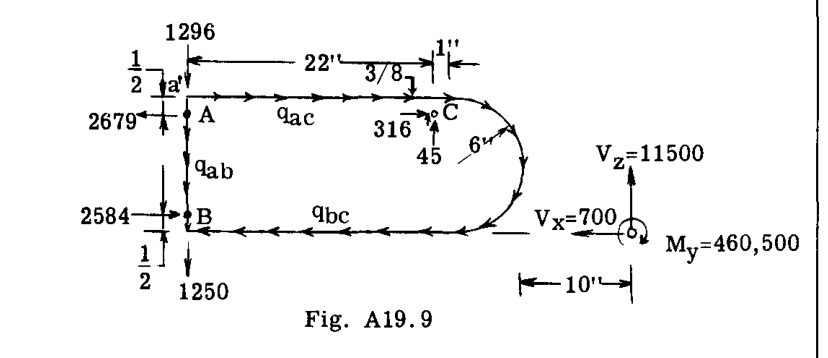

力成分とせん断流の作用方向

$q_{bc}$ を求めるために、点 $(a')$ まわりのモーメントをとる。

$$\Sigma M_{a'} = +2679 \times 0.5 - 2584 \times 11.5 - 316 \times 0.375 - 45 \times 22 + 700 \times 12 - 11500 \times 39 + 460,500 - q_{bc}(665) = 0$$

これより、

となり、仮定した通りの向きを持つ。

上記のモーメント方程式において、点 $(a')$ まわりのせん断流 $q_{bc}$ のモーメントは、 $q_{bc}$ にセルの面積の2倍、すなわち 665 を乗じたものに等しい。

$q_{ac}$ を求めるために、 $\Sigma F_x = 0$ とおき、

$$\Sigma F_x = -2679 + 2584 + 316 + 22 q_{ac} - 22 \times 13.66 - 700 = 0$$

これより、仮定した向きで

$$q_{ac} = 35.45 \text{ lb./in.}$$

となる。

$q_{ab}$ を求めるために、 $\Sigma F_z = 0$ とおき、

$$\Sigma F_z = -1296 - 1250 + 45 + 35.45 \times 0.5 - 11.5 \times 13.66 + 11500 - 11 q_{ab} = 0$$

これより、

$$q_{ab} = 805 \text{ lb./in.}$$

となる。

ストリンガーおよび外板パネルに加わる荷重が決定された。ストリンガーの軸荷重は、軸荷重が $y$ 方向力成分を小角度のコサインで除したものであるため、実質的にそれらの $y$ 成分に等しい。応力エンジニアは、翼幅に沿った多数のステーションにおいて同様の応力を見つけることになる。これらの6つの応力は、一般に一次応力と呼ばれる。通常、ほとんどの構造物には、最終的な部材サイズを決定する前に考慮しなければならない二次的な応力影響が存在する。例えば、ボックスタイプのビームの内部ウェブは、通常、半張力場ビームとして設計される。張力場ビーム理論は、フランジ部材が上記のように見出された一次応力に加えて、追加の応力を受けることを示している。二次応力および与えられた応力荷重を支持するための部材とその接続部の強度設計に関する主題は、後の章で詳しく取り上げる。

## A19.6 例題 2. 単一の外部支柱を持つ金属カバー付き翼

第A2章では、外部支柱で支持された布張りの単葉機翼の応力解析を検討した。十分なねじり強度と剛性を提供するために、2つの外部支柱が必要であった。しかし、翼が金属で覆われている場合は、金属カバーと内部ウェブによって形成された閉じたセルがねじり剛性を提供するため、単一の外部支柱を使用することができ、翼は片持ち式のオーバーハングを持つ単純支持ビームとして設計できる。この種の翼構造の優れた例は、写真に示すセスナ180型機である。これは性能、製造、メンテナンスの容易さにおいて優れた航空機である。

このような翼構造の応力解析の一般的なアプローチを学生に紹介するために、いくつかの計算を伴う限定的な議論を提示する。

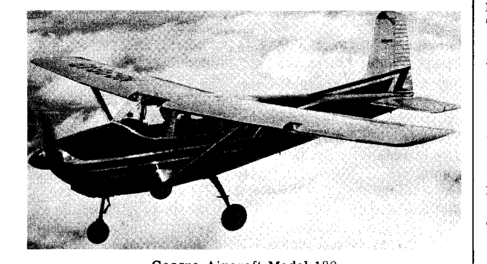

セスナ180機体写真

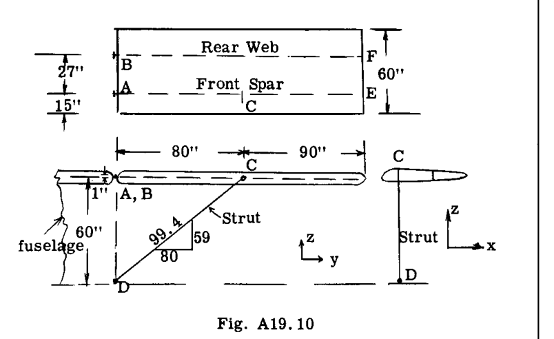

外部支柱を有する翼のレイアウト

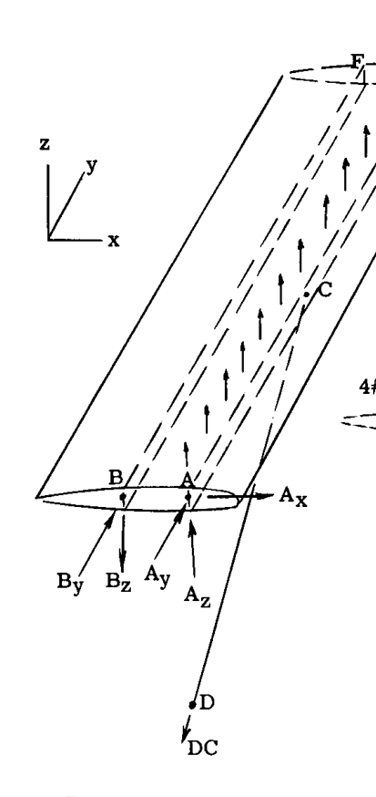

反力と座標軸の定義

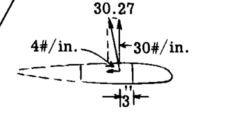

空気荷重の分布

図 A19.10 および 図 A19.11 は、単一の外部支柱を持つ単葉機翼の寸法と一般的な構造レイアウトを示している。翼パネルは、点AおよびBにおける単一のピンフィッティングによって胴体に取り付けられており、ピン軸は $x$ 軸に平行である。点Aのフィッティングの嵌合ラグはぴったりとはめ込まれているが、Bのものは若干の隙間があるため、翼荷重による胴体への抗力反力は、フィッティングAのみで完全に抵抗される。AおよびBのフィッティングは $x$ 軸まわりのモーメントに抵抗できないため、構造を安定させるために外部支柱DCを追加する必要がある。パネル構造は、主桁ACEと後部桁BFで構成されている。パネル全体は、後部桁の前方で金属外板で覆われている。

図 A19.12 に示すように、翼幅1インチあたり $w = 30.27 \text{ lb./in.}$ の均一荷重が翼弦の30%の位置に作用していると簡略化した空気荷重を想定する。この合力を $z$ および $x$ 成分に分解すると、結果は 図 A19.12 に示すように $w_z = 30 \text{ lb./in.}$ および $w_x = 4 \text{ lb./in.}$ となる。

これらの空気荷重を支持する翼構造の一般的な物理的作用は、3つの比較的明確な作用として考えることができる。すなわち、（1）前部桁ACEが荷重 $w_z$ による曲げモーメントとせん断力に抵抗し、（2）2セルチューブの外板とウェブが $y$ 軸まわりのすべてのモーメント、大雑把に言えばねじりモーメントに抵抗し、（3）パネル断面全体が抗力荷重 $w_x$ による曲げモーメントと曲げせん断力に抵抗し、このボックスビームのウェブとして作用する上下の外板と、フランジとして作用する2本の桁が抵抗する。

### 一般計算

未知の外部反力（図 A19.11 参照）は、 $A_y$ 、 $A_z$ 、 $A_x$ 、 $B_y$ 、 $B_z$ 、および $DC$ であり、合計6つである。6つの静的釣り合い方程式が利用可能であるため、反力は静定である。反力 $DC$ は、支柱DCの荷重でもある。

反力 $DC$ を求めるために、点A、Bを通る $x$ 軸まわりのモーメントをとる。

$$\Sigma M_{x(AB)} = (-170 \times 30 \times \frac{170}{2}) + DC \left(\frac{80}{99.4}\right) 60 = 0$$

これより、

$$DC = 8979 \text{ lb.}$$

（符号はプラスで得られるため、図 A19.11 で想定した向きは正しかった。）したがって、支柱の荷重は 8979 lb. の引張である。

$B_y$ を求めるために、点 (A) を通る $z$ 軸まわりのモーメントをとる。

$$\Sigma M_{z(A)} = -\left(4 \times 170 \times \frac{170}{2}\right) + 27 B_y = 0$$

これより、想定した向きに作用する

$$B_y = 2141 \text{ lb.}$$

を得る。

$A_y$ を求めるために、 $\Sigma F_y = 0$ とする。

$$\Sigma F_y = 2141 - 8979 \left(\frac{80}{99.4}\right) + A_y = 0$$

これより、

$$A_y = 5085 \text{ lb.}$$

となる。

$$\Sigma M_y(A) = +(30 \times 170 \times 3) - 27 B_z = 0$$

これより、想定通りに作用する $B_z = 567 \text{ lb.}$ となる。

$A_z$ を求めるために $\Sigma F_z = 0$ とおく。

$$\Sigma F_z = 170 \times 30 - 567 - \left(8979 \times \frac{59}{99.4}\right) + A_z = 0$$

これより、想定通りに作用する $A_z = 796 \text{ lb.}$ を得る。

点AおよびBのフィッティングは、上記で見出されたこれらの点における反力を受けるように設計されるべきである。外部支柱DCとその端部フィッティングは、8979 lb. の引張荷重を支持しなければならない。

次のステップは、翼パネルの構造部品に対する応力と荷重を求めることである。

前部桁ACEは $x$ 軸まわりの曲げモーメントに抵抗しなければならないため、図 A19.12 の空気荷重は、図 A19.13 に示すように桁の中心線に移動される。

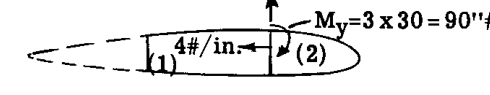

桁中心線に移動された荷重

翼幅1インチあたり 90 in. lb. のねじりモーメントは、2つのセル (1) と (2) で構成されるセルチューブによって抵抗される。多くの設計では、前縁セルは多くのカットアウトなどのためにねじりモーメントへの抵抗において無視されるため、セル1がねじりせん断抵抗のすべてを提供すると仮定することができ、この場合のせん断流は $q = M_t/2A$ となる。ここで、 $M_t$ は与えられたパネル断面におけるねじりモーメントであり、 $A$ はセル (1) の囲まれた面積である。両方のセルが有効であるとみなされた場合、せん断流の解を得る前に外板の厚さが必要になる。多細胞チューブにおけるねじりせん断流の計算については、第A6章を参照されたい。

最大ねじりモーメントは、翼パネルの胴体端に発生し、その大きさは $170 \times 90 = 15300 \text{ in. lb.}$ となる。上下の外板は胴体に取り付けられていないため、このねじりモーメントはパネル端のリブに伝達される必要があり、このリブは、点AおよびBにおいて桁に対するカップル反力の形でこのモーメントを伝達する。このカップル力は、モーメントを桁間の距離で除したものに等しく、すなわち $15300/27 = 566.7 \text{ lb.}$ となる。

$w_z = 30 \text{ lb./in.}$ による前部桁（ACE）の荷重は次のようになる。

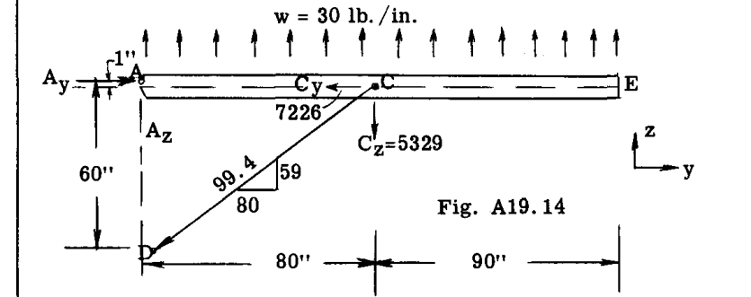

前部桁のフリーボディ図

図 A19.14 は、前部桁ACEのフリーボディ図を示している。支柱荷重DCを求めるために、(A) まわりのモーメントをとる。

$$\Sigma M_A = -\left(30 \times 170 \times \frac{170}{2}\right) + 60 \left(DC \times \frac{80}{99.4}\right) = 0$$

これより、以前に見出された値と一致する $DC = 8979 \text{ lb.}$ の引張を得る。

Cにおける支柱反力の $y$ および $z$ 成分は、次のようになる。

$$C_y = 8979 \left(\frac{80}{99.4}\right) = 7226 \text{ lb.}$$
$$C_z = 8979 \left(\frac{59}{99.4}\right) = 5329 \text{ lb.}$$

これらの値は、図 A19.14 に示されている。

$A_y$ を求めるために、 $\Sigma F_y = 0$ とする。

$$\Sigma F_y = -7226 + A_y = 0 \quad \text{より} \quad A_y = 7226 \text{ lb.}$$

以前に反力 $A_y$ を求めたとき、その値は 5085 lb. であった。この差は、前部桁に引張荷重を、後部桁に圧縮荷重を与える傾向がある抗力曲げモーメントによるものである。

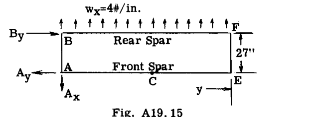

抗力荷重による力分布

図 A19.15 は、翼幅1インチあたり 4 lb. の空気抗力荷重を示している。翼端から距離 $y$ におけるパネルの曲げモーメントは、 $w_x (y)(y/2) = 4y^2/2 = 2y^2$ に等しい。したがって、先端から任意の距離 $y$ におけるいずれかの桁の軸荷重 $P_y$ は、曲げモーメントを 27インチのアームで除したもの、すなわち $P_y = 2y^2/27 = .074y^2$ に等しい。したがって、点AおよびBにおける軸荷重は $.074 \times 170^2 = 2141 \text{ lb.}$ （前部桁で引張、後部桁で圧縮）に等しくなる。このように、各桁は軸荷重を受ける。

先端でのゼロから胴体取り付け点での 2141 lb. まで、 $y^2$ に比例して増加する。前部桁上の点Cにおける軸方向引張荷重は、 $.074(90^2) = 600 \text{ lb.}$ となる。

点CとEの間の前部桁の設計は、曲げ力に加えて軸方向引張荷重とねじりせん断流を受ける片持ち梁にすぎない。点CとAの間の桁の設計は、決定すべきかなりの二次曲げモーメントがあり、これを一次曲げモーメントに加算しなければならないため、はるかに複雑である。図 A19.15a は、桁部分ACのフリーボディ図を示している。

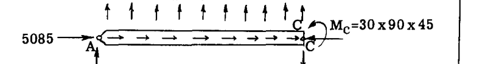

前部桁部分ACのフリーボディ図

1インチあたり 30 lb. の横方向荷重はビームを上方に曲げるため、AとCにおける軸荷重はビームのたわみによるモーメントアームを持つことになり、これらのモーメントは二次モーメントと呼ばれる。たわみを求めるためにはビームの慣性モーメントを知らなければならないため、このビーム部分の設計は試行錯誤の手順になる。第A5章のA5.23から28節では、ビーム・コラム作用を伴う問題の解法を説明および図示しており、このビーム部分の実際の設計にはそのような手順を使用する必要がある。

後部桁BFは、2つの荷重システムを受ける。すなわち、FにおけるゼロからBにおける 2141 lb. までの変化する軸荷重と、この桁のウェブはねじりモーメントからせん断荷重を受ける。後部桁は曲げモーメントを受けない。

図 A9.10 では、翼弦方向リブと外板にリベット留めされた翼幅方向の軽量ストリンガーからなる二次構造は示されていない。この二次構造は、翼の輪郭形状を保持し、空気圧をボックス構造に伝達するために必要である。この二次構造については、第A21章で説明する。応力に安全かつ効率的に耐える部材または構造を設計するという広範な主題は、後の章で詳しく検討する。

## A19.7 単一桁 - 片持ち翼 - 金属カバー

金属カバー付きの単一桁片持ち翼は、特に軽量の商業用または個人パイロット用航空機でよく使用される。

図 A19.11 の単一桁外部支柱付き翼において、外部支柱DCが取り外されたと仮定する。明らかに、翼は点AおよびBのヒンジフィッティングまわりに回転するため、不安定になる。構造を安定させるために、点 (A) の単一ピンフィッティングを、 $M_x$ モメントに抵抗できるように、上部フランジに1つ、下部フランジに1つの計2つのフィッティングに置き換える必要がある。図 A19.16 はこの修正を示している。Bにおけるフィッティングは、以前と同様に単一のピンフィッティングのままでよい。

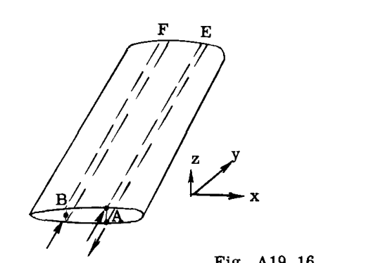

修正された単一桁フィッティング

この翼の応力解析は、すべての $M_x$ モーメントと $V_z$ せん断力に抵抗し、片持ち梁として作用する桁AEで構成される。桁AEと一致する $y$ 軸まわりのねじりモーメントは、外板と桁ウェブによって形成されるセルチューブ内のせん断応力によって抵抗される。抗力曲げおよびせん断力は、前部および後部桁をフランジとし、上下の外板をウェブとするビームによって抵抗される。

## A19.8 薄肉外板 - 多ストリンガー片持ち翼の応力解析。導入と仮定。

最も一般的な翼構造のタイプは、図 A19.2 の6つの例示的な横断面によって示されるような多ストリンガータイプである。多くのストリンガーと外板パネルを持つ構造は、内部応力に関して高次の不静定である。幸いなことに、完成した翼構造の構造試験は、翼幅が翼弦の数倍であり、後退角が小さく、翼に大きなカットアウトや不連続性がない場合、単純なビーム理論が測定された応力と非常によく一致する応力を与えることを示している。したがって、ビーム理論によって翼全体を解析および設計し、その後、第8章のA8.10節で説明および図示されているような、より厳密な解析方法を使用して、ビーム理論が誤っている可能性のある翼の部分を調査するのが一般的な手順である。

### 仮定 - ビーム理論

本章では、非対称ビーム理論を用いて翼の曲げ応力およびせん断応力を計算する。この理論における2つの主な仮定は次のとおりである。

1. 曲げ前に平面であったビームの横断面は、ビームの曲げ後も平面を維持する。この仮定は、縦ひずみが中立軸からの距離に直接比例して変化する、すなわち、ひずみの変化が線形であることを意味する。
2. 縦応力分布はひずみに直接比例するため、仮定 (1) からも線形である。この仮定は、実際には、各縦要素が他のすべての要素から独立しているかのように作用し、フックの法則、すなわち応力-ひずみ曲線が線形であることが成り立つことを意味する。

仮定 (1) は、一般にせん断遅れ効果と呼ばれる、外板内のせん断応力によるひずみを無視している。せん断遅れの影響は、大きなカットアウトやその他の大きな不連続性の近く、また大きな集中外力が加えられる場所以外では、通常重要ではない。

仮定 (2) は、翼の破損前に外板やストリンガーの弾性および非弾性座屈が発生する場合、通常は正しくない。実用的な翼にビーム理論を適用する場合、この仮定の誤差は、後で説明するいわゆる有効断面の使用によって修正される。

## A19.9 ゼロから破壊荷重までの外部曲げ力に対する翼断面の物理的作用

図 A19.17 は、一般に分散フランジ型と呼ばれる一般的なタイプの翼横断面構造配置を示している。

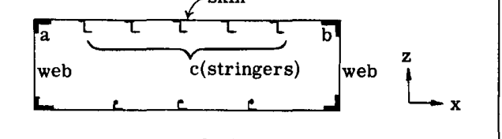

分散フランジ型の翼断面

コーナー部材 (a) および (b) は、ストリンガー (c) よりも面積がかなり大きい。外板は比較的薄い。ここで、翼に徐々に増加する曲げ力が加わり、この翼断面の上部が圧縮、下部が引張状態になると仮定する。小さな荷重下では、上面の圧縮応力は小さく、応力はひずみに直接比例し、ビーム公式 $\sigma_c = M_x z / I_x$ が適用され、慣性モーメント $I_x$ にはすべての断面積が含まれる。外力がさらに増加すると、薄い板の圧縮応力によって板パネルが座屈し始め、ひずみがさらに継続すると抵抗が急速に低下する。言い換えれば、板が座屈すると、応力はひずみに直接比例しなくなる。しかし、外板パネルの座屈は、ストリンガーやコーナー部材がそれらの破壊応力と比較して低い応力状態にあるため、ビームの破壊を引き起こさない。ストリンガー (c) は、翼リブの点で横方向に支持されているだけであり、したがってストリンガーは柱として作用し、弾性または非弾性曲げによって破損する。コーナーフランジ部材 (a) および (b) は、外板およびウェブによって2方向に安定化されており、通常は局所的なクリップリングによって破損する。

ここで、外板が座屈した後の翼への荷重を継続すると、ストリンガーとコーナー部材は追加の圧縮応力を受け続ける。ストリンガーの極限強度はコーナー部材の極限強度よりも低いため、ストリンガー (c) は弾性的または非弾性的に曲がり始め、追加のひずみが発生しても実質的にそれ以上の応力を受けなくなる。コーナー部材は依然としてかなりの余力を持っているため、最終的にコーナー部材の極限強度に達し、ビーム断面の上部が完全に破壊されるまで、追加の外部荷重を加えることができる。したがって、このような構造が破壊荷重まで負荷された場合、真の応力-ひずみ関係はフックの法則に従わない。

上記の議論において、ストリンガー (c) は、かなりの追加の軸方向ひずみの間、それらの極限座屈荷重を維持すると考えられていた。これは、実用的な柱をテストすることによって実験的に検証できる。実用的な柱は、真直度や材料の均一性などに関して完全ではない。図 A19.18 は、柱が荷重を受けて弾性曲げによって破損する際の、柱の中点における横方向たわみに対する荷重のグラフを示している。図 A19.19 は、破損が非弾性曲げである場合の同様の結果を示している。

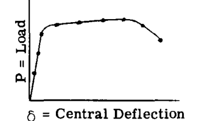

弾性座屈

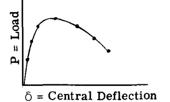

非弾性座屈

試験結果は、曲げで破損する圧縮部材が、通常、かなりの追加の軸方向変形の下でもほぼ最大荷重を維持し続けることを示している。したがって、図 A19.17 のビーム断面において、ストリンガー (c) が極限荷重に達しても、コーナー部材 (a) および (b) にまだ強度の余裕があるため、ビームの破壊はすぐには起こらない。

## A19.10 極限強度設計要件

強度設計要件は以下の通りである。

1. 制限荷重（または実用荷重）の下で、いかなる構造部材も材料の降伏点を超える応力を受けてはならない。言い換えれば、構造のいかなる部分にも永久変形やたわみが発生してはならない。